# Week 3 - NYPD Data - RMD

Student

2024-12-09

This is an R Markdown document for my analysis, visualization, and modeling of data recorded by New York City Police Department (NYPD) regarding shooting occurrences in the various boroughs in New York City, New York.

## **Visual One**

To reproduce this analysis, you will need to install and utilize features from the following packages:

-dplyr, -ggplot2,

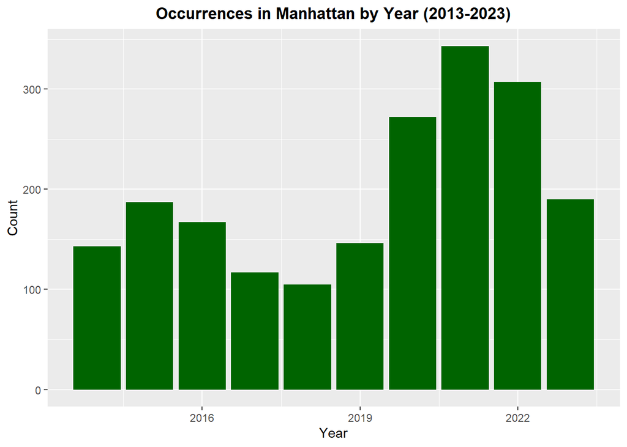

```r
library(dplyr)
library(ggplot2)

##Load data from URL##

urls_in <- "https://data.cityofnewyork.us/api/views/833y-fsy8/rows.csv?accessType=DOWNLOAD"
NYPD_data <- read.csv("https://data.cityofnewyork.us/api/views/833y-fsy8/rows.csv?accessType=DOWNLOAD")

##Select "Relevant" columns for analysis. Filtering to Manhattan Borough data, only. Format date for our analysis ##

visualone <- select(NYPD_data, BORO, OCCUR_DATE)
  NYPD_data$wholedate <- as.Date(NYPD_data$OCCUR_DATE, format = "%m/%d/%Y")
  NYPD_data$year <- format(NYPD_data$wholedate, "%Y")
  countmanhattan <- sum(grepl("MANHATTAN", NYPD_data$BORO, ignore.case = TRUE))

##Create list to store count of results##

  manhattanResults <- list(
    count = countmanhattan,
    matching_rows = NYPD_data[grepl("MANHATTAN", NYPD_data$BORO, ignore.case = TRUE),]
  )
##Filter data by Manhattan Borough##

manhattan_summary <- NYPD_data %>%
  filter(BORO == "MANHATTAN") %>%
  group_by(year) %>%
  summarize(count = n())

##Filter data between 2013 and 2023##

manhattan_summary <- manhattan_summary %>%
  mutate(year = as.numeric(year)) %>%
  filter(year > 2013)

##Create Plot##

ggplot(manhattan_summary, aes(x = year, y = count)) +
    geom_bar(fill = "darkgreen", stat = "identity") +
    labs(title = "Occurrences in Manhattan by Year (2013-2023)",
    x = "Year",
    y = "Count") +
    theme(plot.title = element_text(hjust = 0.5, face = "bold"))
```

## **Visual Two**

Here you will find a “Heat Map” of Shooting Incidents by year and month. I thought this would be an interesting visual to help identify some a bias in our data. Below, I’ve filtered out data to show the last five years of records. During the calendar year of 2020, there were several large events that took place in that could be attributed to an increase in Shooting Incidents, particularly in late June and July.

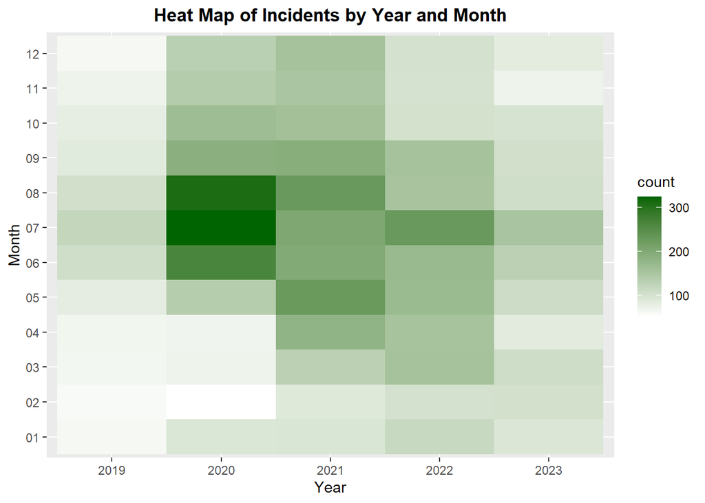

```r
library(ggplot2)

## Load the data from URL ##

url <- "https://data.cityofnewyork.us/api/views/833y-fsy8/rows.csv?accessType=DOWNLOAD"
NYPD_data <- read.csv(url)

## Reformat date to enable analysis of data by year and month ##
NYPD_data$wholedate <- as.Date(NYPD_data$OCCUR_DATE, format = "%m/%d/%Y")
NYPD_data$year <- format(NYPD_data$wholedate, "%Y")
NYPD_data$month <- format(NYPD_data$wholedate, "%m")

##Filter data to last five years##

filteredData2 <- NYPD_data %>%
  filter(year>2018)

## Summarize filtered data for map##
heatmap_data <- filteredData2 %>%
  group_by(year, month) %>%
  summarize(count = n())

## Create map ##
ggplot(heatmap_data, aes(x = year, y = month, fill = count)) +
  geom_tile() +
  scale_fill_gradient(low = "white", high = "darkgreen") +
  labs(title = "Heat Map of Incidents by Year and Month",
    x = "Year",
    y = "Month") +
  theme(plot.title = element_text(hjust = 0.5, face = "bold"))
```

## **Data Model**

Because I use Manhattan in my first Visualization, I decided to continue this theme in my Data Model. I’ve used our historical data to model a prediction for Shooting Incidents in Manhattan in 2024.

```r
library(dplyr)
library(ggplot2)

# Load the data
urls_in <- "https://data.cityofnewyork.us/api/views/833y-fsy8/rows.csv?accessType=DOWNLOAD"
NYPD_data <- read.csv(urls_in)

# Select relevant columns and create the wholedate and year columns
visualone <- select(NYPD_data, BORO, OCCUR_DATE)
NYPD_data$wholedate <- as.Date(NYPD_data$OCCUR_DATE, format = "%m/%d/%Y")
NYPD_data$year <- as.numeric(format(NYPD_data$wholedate, "%Y"))

# Filter data for Manhattan
manhattan_data <- NYPD_data %>% filter(BORO == "MANHATTAN")

# Aggregate data by year
manhattan_summary <- manhattan_data %>%
group_by(year) %>%
summarize(count = n())

# Split the data into training and testing sets
set.seed(123)
trainIndex <- sample(seq_len(nrow(manhattan_summary)), size = 0.8 * nrow(manhattan_summary))
trainData <- manhattan_summary[trainIndex, ]
testData <- manhattan_summary[-trainIndex, ]

# Train the linear regression model
model <- lm(count ~ year, data = trainData)
```

[output not shown]

Next we’ll generate predictions to test our Data Model.

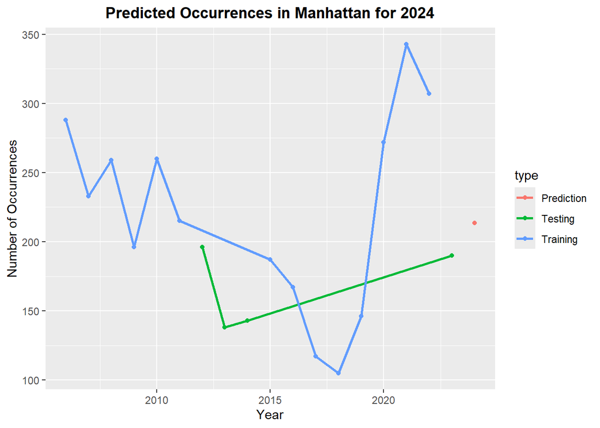

```r
##Test predictions in this model and record for analysis##
predictions <- predict(model, newdata = testData)
actuals <- testData$count

##Calculate the Mean Squared Error and Root Mean Squared Error for the Data Model##
mse <- mean((predictions - actuals)^2)
rmse <- sqrt(mse)

##Model predictions for 2024##
future_year <- data.frame(year = 2024)
future_prediction <- predict(model, newdata = future_year)


##Combine data and create visual##
combined_data <- rbind(
  data.frame(year = trainData$year, count = trainData$count, type = "Training"),
  data.frame(year = testData$year, count = testData$count, type = "Testing"),
  data.frame(year = future_year$year, count = future_prediction, type = "Prediction")
)

ggplot(combined_data, aes(x = year, y = count, color = type)) +
  geom_line(linewidth = 1) +
  geom_point(linewidth = 2) +
  labs(title = "Predicted Occurrences in Manhattan for 2024",
    x = "Year",
    y = "Number of Occurrences") +
theme(plot.title = element_text(hjust = 0.5, face = "bold"))
```

Per our Data Model, we can predict there will be approximately 213 Shooting Incidents in Manhattan in 2024.